## Welcome Back !

These slides: http://www.databrew.cc/class2

## How was the homework?

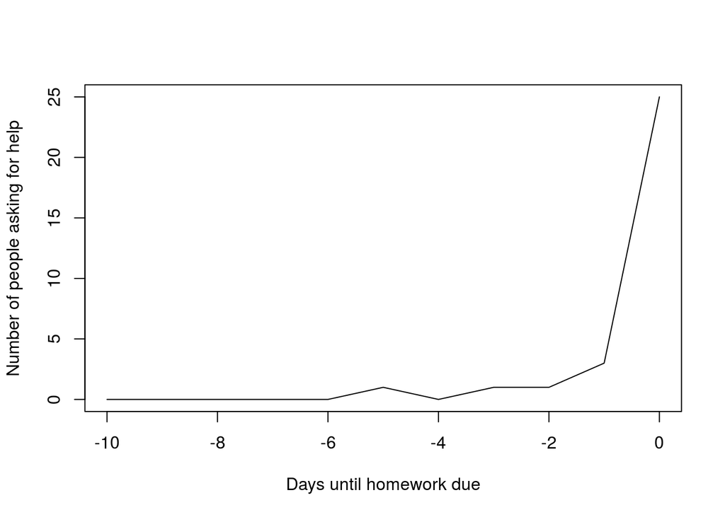

## Comments on homework

- Use comments
- Send the R script
- It’s okay to have problems.
- It’s supposed to be hard!

## Difficulty

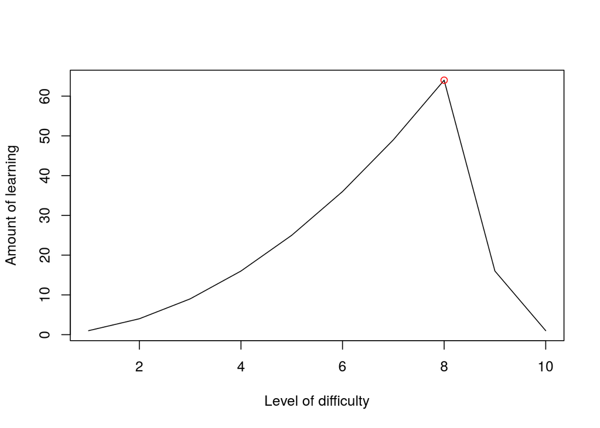

## For next homework

- Ask for help!
- Ask early.
- Ask often.
- Ask by email.
- Include error messages.

## Review of rules

- Be on time (class starts at 15:00 exactly)
- Do your homework
- Ask for help

## Review

```r
library(databrew)
frangos <- databrew::frangos
```

## Census

```r
library(databrew)
library(cism)
census <- databrew::census
```

## Some questions

1. How many people in the data have a motorcycle.
2. Make a table called `floors` with the different types of floor materials.
3. Make a barplot of the `floors` table.
4. Make a dataframe of only those people without floors.
5. Make a map of only those people without floors.

## Some more questions

6. Make a map of *all* people using `cism_map`, and color the map by the “floor_material” variable.
7. Make a map of only those people without floors, and color the map by the “sex” variable.
8. Make a table called `xt`. This will be a cross-table of the “moto” and “bike” variables.
9. Use `chisq.test` on the `xt` table to see if their is a significant correlation between having a motorcycle and having a bike.